# Lec5

# 1. Slides: Two Way ANOVA

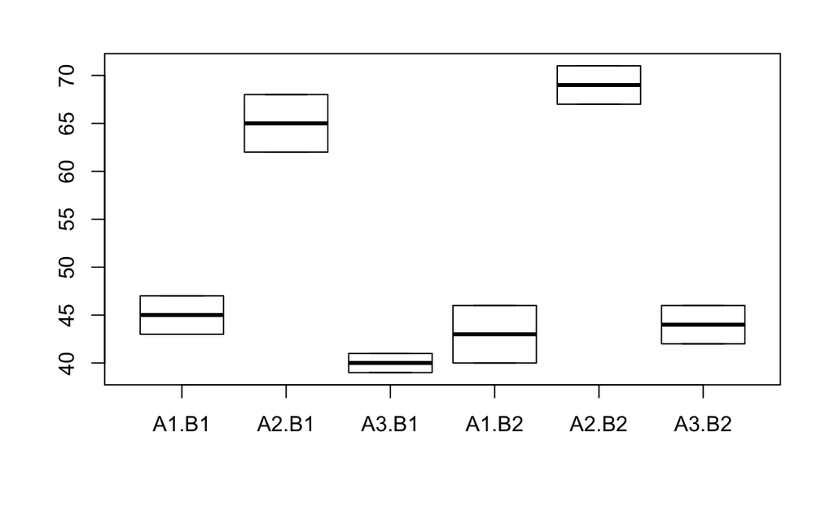

```r
#prepare data
response<-c(47,43,62,68,41,39,46,40,67,71,42,46)
A<-c(rep(c(rep("A1",2),rep("A2",2),rep("A3",2)),2))
B<-c(rep("B1",6),rep("B2",6))
boxplot(response~A*B)
```

A: 3 levels  
B: 2 levels  
a=3, b=2, n=2  
因为数据少，可以在x轴上把每种treatment组合展开显示。

```r
tapply(response, list(A), mean)
```

```
A1 A2 A3
44 67 42
```

```r
tapply(response, list(A), mean)
```

```
A1 A2 A3
44 67 42
```

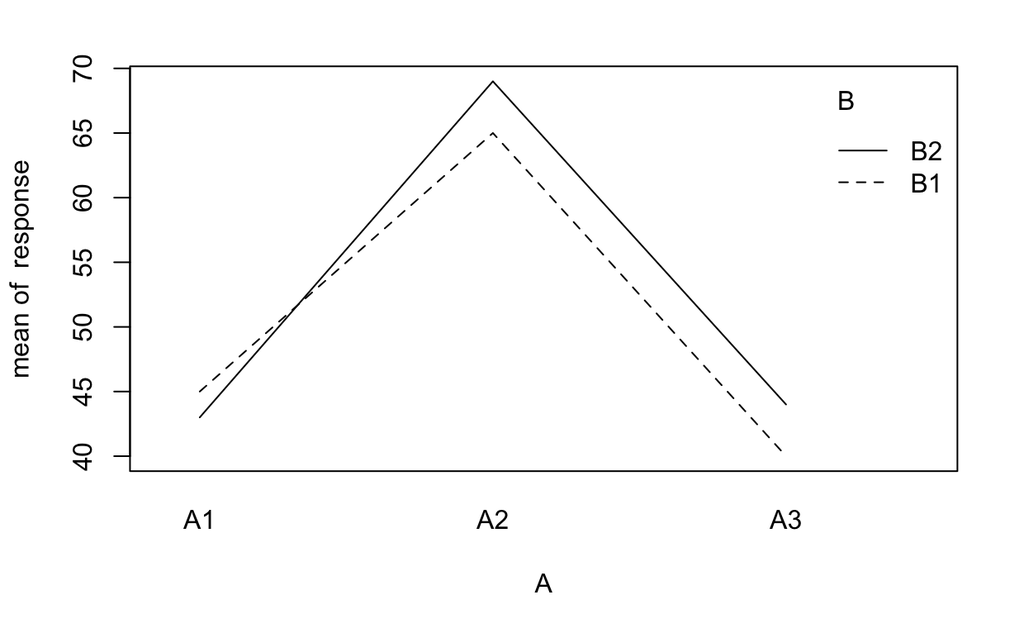

实线与虚线间的差别：比如A1点上，就是compare levels of B at A1.

#### Step 1. Look at interaction first

```r
summary(aov(response~A*B))
```

```
            Df Sum Sq Mean Sq F value   Pr(>F)
A            2   1544   772.0  74.710 5.75e-05 ***
B            1     12    12.0   1.161    0.323
A:B          2     24    12.0   1.161    0.375
Residuals    6     62    10.3
---
Signif. codes:  0 ‘***’ 0.001 ‘**’ 0.01 ‘*’ 0.05 ‘.’ 0.1 ‘ ’ 1
```

From ANOVA table above, total # = abn = 12. df(A) = a-1 = 2, df(B) = b-1 = 1, df(AB) = (a-1)(b-1) = 2, df(Residuals) = ab(n-1) = 6.

尽管A的p-value很小，但是**Focus on interaction first**. 这里accept no interaction. 那么interaction的df被residuals吸收。 No interaction，前面的曲线应该不交叉（平行的上下两个折线）。

#### Step 2. Model without interaction

```r
#Model without interaction:
summary(aov(response~A+B))
```

```
            Df Sum Sq Mean Sq F value   Pr(>F)
A            2   1544   772.0  71.814 7.75e-06 ***
B            1     12    12.0   1.116    0.322
Residuals    8     86    10.8
---
Signif. codes:  0 ‘***’ 0.001 ‘**’ 0.01 ‘*’ 0.05 ‘.’ 0.1 ‘ ’ 1
```

另一方面，由于B的影响可以忽略，B1和B2应该是重叠——一条折线。由于error(randomness)，导致现在的情况。

#### Step 3. 不确定是不是都减到一个factor

```r
summary(aov(response~A))
```

```
            Df Sum Sq Mean Sq F value  Pr(>F)
A            2   1544   772.0    70.9 3.1e-06 ***
Residuals    9     98    10.9
---
Signif. codes:  0 ‘***’ 0.001 ‘**’ 0.01 ‘*’ 0.05 ‘.’ 0.1 ‘ ’ 1
```

#### Step 4. Pairwise comparisons

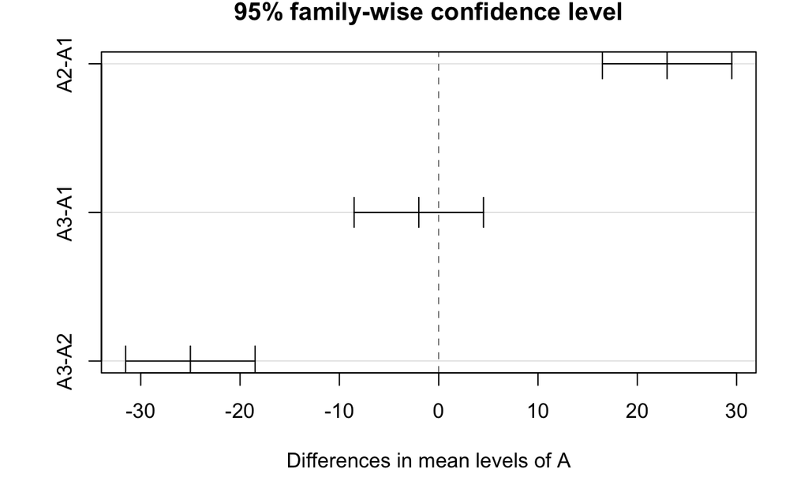

```r
fit<-aov(response~A)
tk<-TukeyHSD(fit, "A")
plot(tk)
```

```r
tk
```

```
  Tukey multiple comparisons of means
    95% family-wise confidence level

Fit: aov(formula = response ~ A)

$A
      diff       lwr       upr     p adj
A2-A1   23  16.48532  29.51468 0.0000108
A3-A1   -2  -8.51468   4.51468 0.6789461
A3-A2  -25 -31.51468 -18.48532 0.0000054
```

So two groups {A1, A3} and {A2}. We could see the group division from the plot too. For 95% family CI, only CI of (A3-A1) covers 0. So no difference between A1 and A3. CI for (A2-A1) positive, so A2 > A1; similarly, A3 < A2.

Family CI: joint statements 同时成立，总共的confidence 是95%. 为了joint statement成立，必须要adjust单个的置信度。 我们现在有三个方法：Bonf, Scheffe and Tukey.